# CodeClan Final Project: UK Productivity

Colin Scotland | DE13

30/05/2022

```
## here() starts at C:/Users/colin/Documents/CodeClan_Final_Project
```

```
## [1] "C:/Users/colin/Documents/CodeClan_Final_Project"
```

# Initial Plots

## UK Output per Hour Ranking v Europe

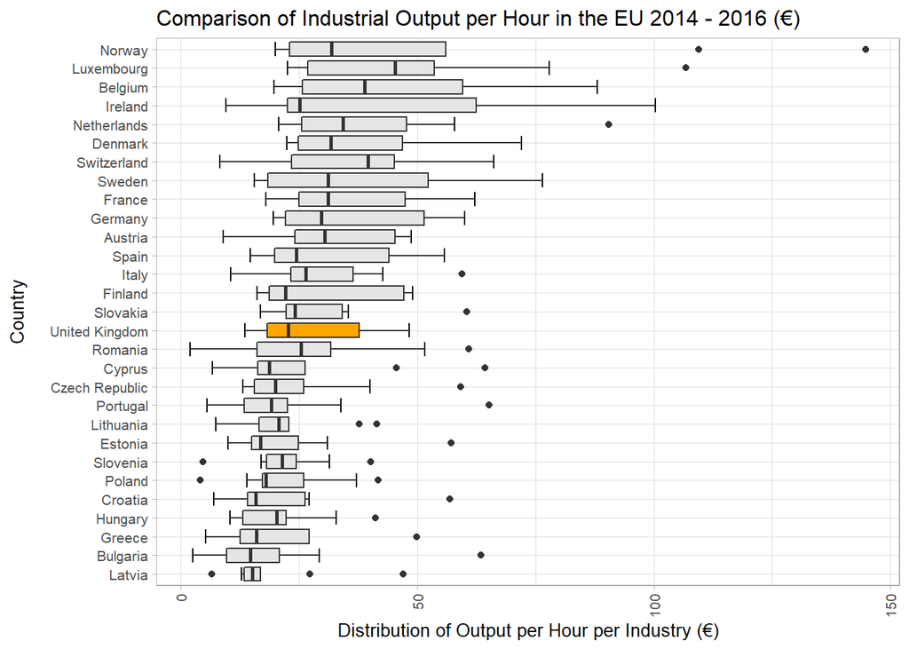

```r
# UK Output per Hour Ranking v Europe ----


europe_labour_prod %>%
  group_by(country) %>%
  ggplot() +
  aes(x = reorder(country, value),
      y = value,
      group = country,
      fill = country == "United Kingdom") +
  stat_boxplot(geom = "errorbar") +
  geom_boxplot(show.legend = FALSE) +
  scale_fill_manual(values = c("grey90", "orange")) +
  theme_light(base_size = 10) +
  theme(axis.text.x = element_text(angle=90, vjust=.5, hjust=1))+
  labs(x = "Country\n",
       y = "Distribution of Output per Hour per Industry (€)",
       title = "Comparison of Industrial Output per Hour in the EU 2014 - 2016 (€)") +
  coord_flip()
```

The boxplot shows that despite the UK’s political stance on the global stage and it’s reputation as a financial powerhouse, in reality the overall productivity is at best fairly mediocre even when compared to countries within the EU.

Spain’s recent history has seen high unemployment and even depopulation in certain interior regions, yet it ranks better than the UK. Successive UK governments have looked to minimise the strength of trade unions, yet countries in which trade unions remain powerful and are often associated with strike action, such as France and Germany are also ranked above the UK.

Ireland, our nearest neighbour with an education and industrial profile very similar to the UK comes far higher up in the rankings, which begs the question “what is UK industry not getting right?”. However, it is also clear that there is a lot of overlap throughout all nations, so;

### Is the difference between Norway and the UK statistically significant?

## Hypothesis Test of Significance between UK and Norway Productivity

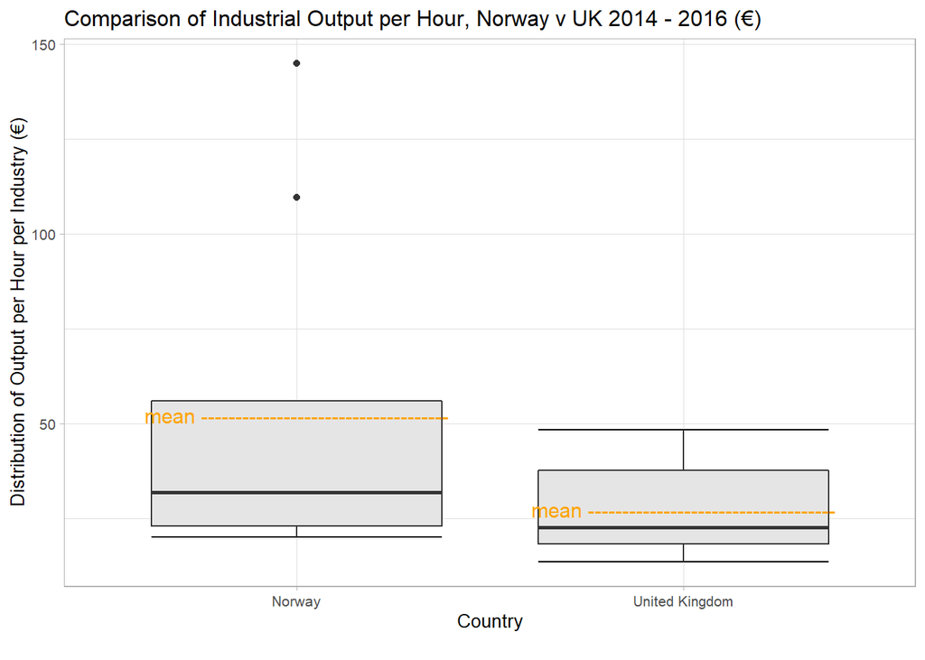

```r
europe_labour_prod %>%
  group_by(country) %>%
  filter(country == "Norway"| country == "United Kingdom") %>%
  ggplot() +
  aes(x = country,
      y = value,
      group = country,
      fill = country == "United Kingdom") +
  stat_boxplot(geom = "errorbar") +
  geom_boxplot(show.legend = FALSE, fill = "grey90") +
  stat_summary(fun.y = "mean",
               geom = "text",
               label="mean ------------------------------------",
               size= 4,
               color= "orange") +
  theme_light(base_size = 10) +
  labs(x = "Country\n",
       y = "Distribution of Output per Hour per Industry (€)",
       title = "Comparison of Industrial Output per Hour, Norway v UK 2014 - 2016 (€)")
```

The data for Norway is right-skewed and this has affected the mean relative to the overall distribution. Consequently, median will be used in this hypothesis test.

The hypotheses under test are, with α = 0.05;

H0: The average output per hour in Norway is the same as in the UK

$$H_0 : x͂_{Norway} - x͂_{UK} = 0$$

H1: The average output per hour in Norway is significantly higher than in the UK

$$H_1 : x͂_{Norway} - x͂_{UK} > 0$$
In this case the median will be used, because the mean (dotted orange line on the boxplot above) is badly right skewed by outliers in Norway.

```r
uk_norway <- europe_labour_prod %>%
  filter(country %in% c("United Kingdom", "Norway")) %>%
  group_by(country) %>%
  select(-c(industry_group, industry))
```

Permutation to generate the null distribution

By randomly shuffling (i.e. permuting) the locations labels we lose any relationship that there was between location and price. Think of this shuffling as detaching the labels from rows and then randomly assigning them back to rows. Then we see which of the following occurs: If there was no relationship in the first place (i.e. they are in fact independent) then randomly shuffling them should have no implication. If the difference between groups in our sample is much larger than the difference once the labels are shuffled it’s because there is a real difference between the groups, and it’s not just down to sampling variation.

Calculate the null sampling distribution;

```r
null_distribution <- uk_norway %>%
  specify(value ~ country) %>%
  infer::hypothesize(null = "independence") %>%         # 'infer' masked by 'fable'
  infer::generate(reps = 1000, type = "permute") %>%    # 'infer' masked by 'fable'
  calculate(stat = "diff in medians", order = c("Norway", "United Kingdom"))
# sample stat is median of Norway minus median of UK, so this is the order
# we specify in the calculate step

head(null_distribution)
```

```
## Response: value (numeric)
## Explanatory: country (factor)
## Null Hypothesis: independence
## # A tibble: 6 x 2
##   replicate   stat
##       <int>  <dbl>
## 1         1   6.46
## 2         2  14.8
## 3         3 -10.9
## 4         4   8.99
## 5         5  -8.99
## 6         6 -11.0
```

And now visualise the observed stat against the null distribution;

```r
observed_stat_norway_uk <- uk_norway %>%
  specify(value ~ country) %>%
  calculate("diff in medians", order = c("Norway", "United Kingdom"))

observed_stat_norway_uk
```

```
## Response: value (numeric)
## Explanatory: country (factor)
## # A tibble: 1 x 1
##    stat
##   <dbl>
## 1  9.23
```

H1 is a “greater than” clause, so that means this is a one-sided test in the “right” direction.

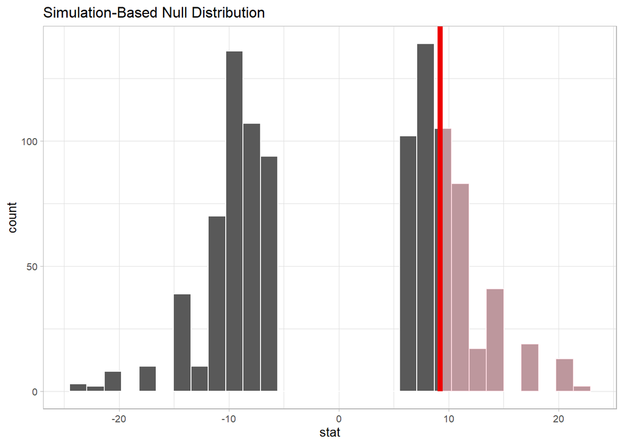

```r
null_distribution %>%
  visualise(bins = 30) +
  theme_light(base_size = 10) +
  shade_p_value(obs_stat = observed_stat_norway_uk, direction = "right")
```

This gives a p-value of;

```r
p_value <- null_distribution %>%
  get_p_value(obs_stat = observed_stat_norway_uk, direction = "right")
p_value
```

```
## # A tibble: 1 x 1
##   p_value
##     <dbl>
## 1   0.229
```

# European Education Levels

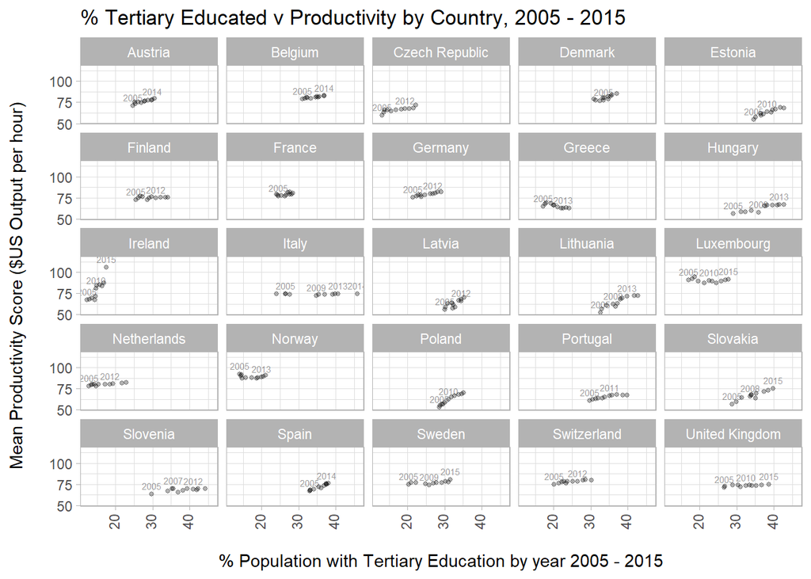

```r
eu_lab_edu %>%
  ungroup() %>%
  ggplot() +
  aes(x = education_score, y = avg_prod) +
  geom_point(size = 1, alpha = 0.3) +
  facet_wrap( ~ country) +
  theme_light() +
  theme(axis.text.x = element_text(angle = 90, vjust = 0.3)) +
  labs(title = "% Tertiary Educated v Productivity by Country, 2005 - 2015",
       x = "\n% Population with Tertiary Education by year 2005 - 2015",
       y = "Mean Productivity Score ($US Output per hour)\n") +
  scale_y_continuous(breaks = seq(50, 100, by = 25)) +
  geom_text(aes(label = year),
            color = "black",
            size = 2,
            nudge_y = 10,
            check_overlap = TRUE,
            alpha = 0.4)
```

The faceted scatterplot above suggests no obvious correlation between education level and productivity level per country over time. A correlation matrix might shed some more light on this:

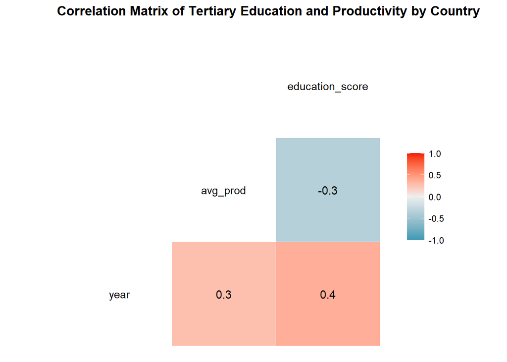

```r
eu_lab_edu %>%
  select(year, avg_prod, education_score) %>%
  ggcorr(label = TRUE) +
  labs(title = "Correlation Matrix of Tertiary Education and Productivity by Country") +
  theme(title = element_text(face = "bold"))
```

The data actually suggests a weak negative correlation between productivity and proportion of the workforce who have gone through tertiary education. In other words, a weak suggestion that the lower the proportion of educated individuals, the higher the national productivity!

The matrix also suggests that there is weak correlation between productivity and year for the data used.

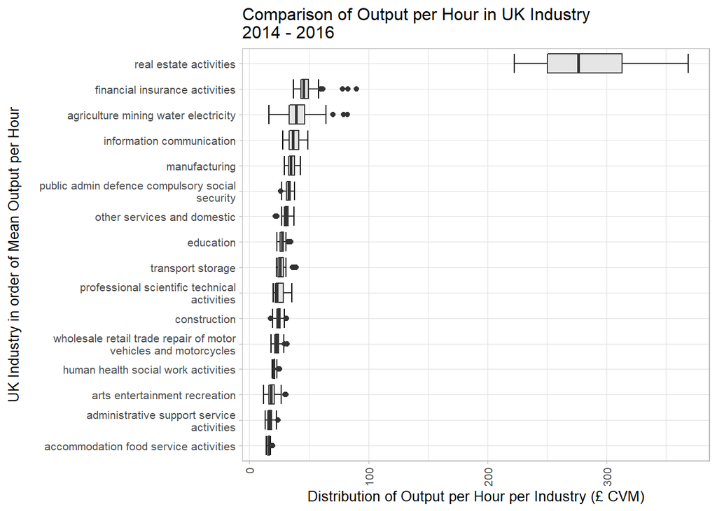

```r
# Limit timeframe to 2014 - 2016 to maintain consistency with EU data

region_by_industry_output_joined %>%
  filter(year >= 2014) %>%
  group_by(industry_group) %>%
  ggplot() +
  aes(x = reorder(industry_group, pounds_per_hour_worked),
      y = pounds_per_hour_worked,
      group = industry_group) +
  stat_boxplot(geom = "errorbar") +
  geom_boxplot(show.legend = FALSE, fill = "grey90") +
  theme_light(base_size = 10) +
  theme(axis.text.x = element_text(angle=90, vjust=.5, hjust=1))+
  labs(x = "UK Industry in order of Mean Output per Hour\n",
       y = "Distribution of Output per Hour per Industry (£ CVM)",
       title = "Comparison of Output per Hour in UK Industry\n2014 - 2016") +
  scale_x_discrete(labels = wrap_format(40)) +
  coord_flip()
```

This boxplot shows the distribution of output in pounds per hour worked per industry between 2014 - 2016.

The plot clearly shows that real estate was by far the largest contributor to financial productivity in this timeframe.

Among the rest of the industries, the plot shows that the hourly output of financial, agriculture and information communication contribute on average a larger financial output per hour worked than for example, administrative support, accommodation and arts and entertainment.

It’s also clear from the plot that there is a good deal of overlap through almost all industry groups outside of real estate, i.e. there are no single industry groups that stand alone as being worse than all others.

# Time Series Productivity Per Industry

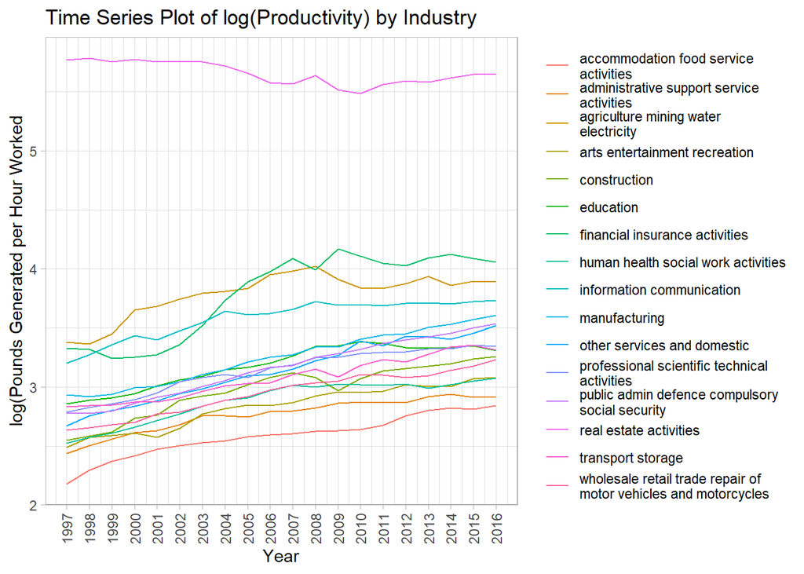

```r
region_by_industry_output_joined %>%
  filter(region == "uk") %>%
  group_by(industry_group) %>%
  ggplot() +
  aes(x = year,
      y = log(pounds_per_hour_worked),
      group = industry_group,
      colour = industry_group) +
  theme_light() +
  scale_colour_discrete(labels = function(x) str_wrap(x, width = 35)) +
  theme(legend.title = element_blank(),
        axis.text.x = element_text(angle = 90, hjust = 1, vjust = 0.5)) +
  geom_line() +
  labs(title = "Time Series Plot of log(Productivity) by Industry",
       x = "Year",
       y = "log(Pounds Generated per Hour Worked") +
  scale_x_continuous(breaks=seq(1997, 2022, 1))
```

## UK Output per Hour per Region

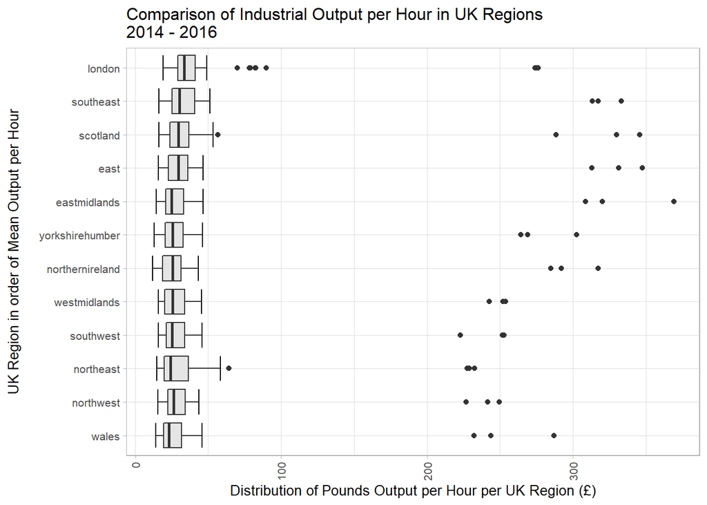

```r
# Limit timeframe to 2014 - 2016 to maintain consistency with EU data


region_by_industry_output_joined %>%
  filter(year >= 2014) %>%
  filter(region != "uk") %>%
  group_by(region) %>%
  ggplot() +
  aes(x = reorder(region, pounds_per_hour_worked),
      y = pounds_per_hour_worked,
      group = region) +
  stat_boxplot(geom = "errorbar") +
  geom_boxplot(show.legend = FALSE, fill = "grey90") +
  theme_light(base_size = 10) +
  theme(axis.text.x = element_text(angle=90, vjust=.5, hjust=1))+
  labs(x = "UK Region in order of Mean Output per Hour\n",
       y = "Distribution of Pounds Output per Hour per UK Region (£)",
       title = "Comparison of Industrial Output per Hour in UK Regions\n2014 - 2016") +
  scale_x_discrete(labels = wrap_format(40)) +
  coord_flip()
```

Comparison of the hourly output per UK region also shows a lot of overlap, with London at the top.

## Hypothesis Test of Significance between London and Wales

First of all, it would help to visualise this comparison in more detail;

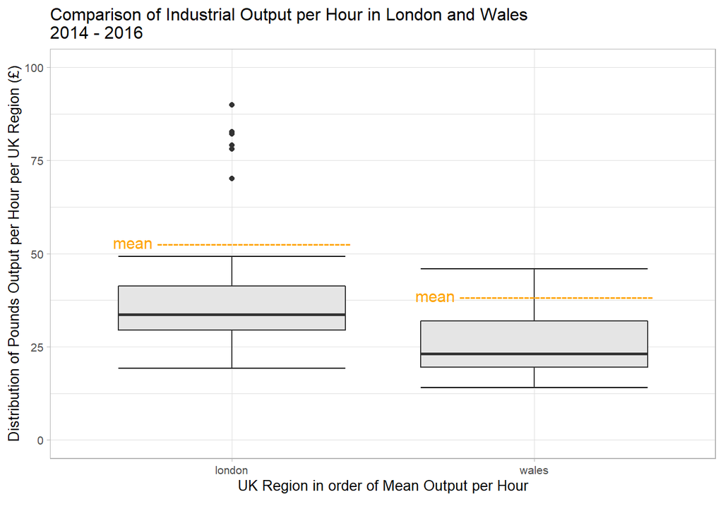

```r
region_by_industry_output_joined %>%
  filter(year >= 2014) %>%
  filter(region == "london" | region == "wales") %>%
  group_by(region) %>%
  ggplot() +
  aes(x = region,
      y = pounds_per_hour_worked,
      group = region) +
  stat_boxplot(geom = "errorbar") +
  geom_boxplot(show.legend = FALSE,
               fill = "grey90") +
  stat_summary(fun.y = "mean",
               geom = "text",
               label="mean ------------------------------------",
               size= 4,
               color= "orange") +
  theme_light(base_size = 10) +
  labs(x = "UK Region in order of Mean Output per Hour\n",
       y = "Distribution of Pounds Output per Hour per UK Region (£)",
       title = "Comparison of Industrial Output per Hour in London and Wales\n2014 - 2016") +
  scale_x_discrete(labels = wrap_format(40)) +
  coord_cartesian(xlim = c(), ylim = c(0, 100))
```

```r
# Use coord cartesian to limit the axis scales so that the mean and median are
# not affected (they are affected if scale_y_continuous(limits = ) is used)
```

The hypotheses for this are as follows, with α = 0.05;

H0: The average output per hour in London is the same as in Wales

$$H_0 : x͂_{London} - x͂_{Wales} = 0$$

H1: The average output per hour in London is significantly higher than in Wales

$$H_1 : x͂_{London} - x͂_{Wales} > 0$$
In this case the median will be used, because the mean (dotted orange line on the boxplot above) is badly right skewed by outliers in both data sets.

```r
london_wales <- region_by_industry_output_joined %>%
  filter(year >= 2014) %>%
  filter(region %in% c("wales", "london")) %>%
  group_by(region) %>%
  select(-c(year, industry))
```

Permutation to generate the null distribution

By randomly shuffling (i.e. permuting) the locations labels we lose any relationship that there was between location and price. Think of this shuffling as detaching the labels from rows and then randomly assigning them back to rows. Then we see which of the following occurs: If there was no relationship in the first place (i.e. they are in fact independent) then randomly shuffling them should have no implication. If the difference between groups in our sample is much larger than the difference once the labels are shuffled it’s because there is a real difference between the groups, and it’s not just down to sampling variation.

Calculate the null sampling distribution;

```r
null_distribution <- london_wales %>%
  specify(pounds_per_hour_worked ~ region) %>%
  infer::hypothesize(null = "independence") %>%           # 'infer' masked by 'fable'
  infer::generate(reps = 1000, type = "permute") %>%      # 'infer' masked by 'fable'
  calculate(stat = "diff in medians", order = c("london", "wales"))
# sample stat is median of London minus median of Wales, so this is the order
# we specify in the calculate step

head(null_distribution)
```

```
## Response: pounds_per_hour_worked (numeric)
## Explanatory: region (factor)
## Null Hypothesis: independence
## # A tibble: 6 x 2
##   replicate   stat
##       <int>  <dbl>
## 1         1  0.897
## 2         2  1.41
## 3         3  0.466
## 4         4 -4.02
## 5         5 -2.04
## 6         6 -2.18
```

And now visualise the observed stat against the null distribution;

```r
observed_stat_lond_wal <- london_wales %>%
  specify(pounds_per_hour_worked ~ region) %>%
  calculate("diff in medians", order = c("london", "wales"))

observed_stat_lond_wal
```

```
## Response: pounds_per_hour_worked (numeric)
## Explanatory: region (factor)
## # A tibble: 1 x 1
##    stat
##   <dbl>
## 1  10.5
```

H1 is a “greater than” clause, so that means this is a one-sided test in the “right” direction.

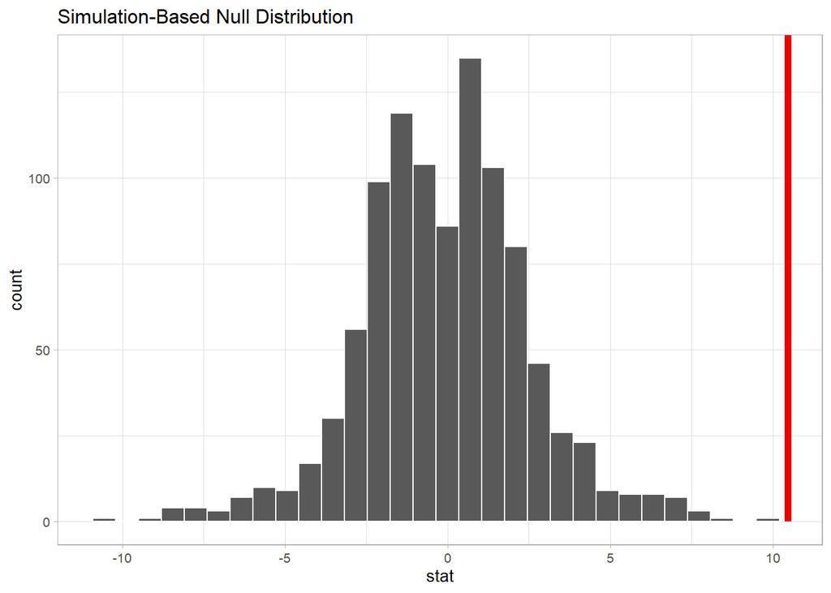

```r
null_distribution %>%
  visualise(bins = 30) +
  theme_light(base_size = 10) +
  shade_p_value(obs_stat = observed_stat_lond_wal, direction = "right")
```

This gives a p-value of;

```r
p_value <- null_distribution %>%
  get_p_value(obs_stat = observed_stat_lond_wal, direction = "right")
p_value
```

```
## # A tibble: 1 x 1
##   p_value
##     <dbl>
## 1       0
```

The p-value is less than α = 0.05. In this case we reject the null hypothesis and can say that for this data there is a significant difference between the median hourly output in London when compared to the median hourly output in Wales.

## Output by Industry by Region

One other point of interest is the output per industry per region;

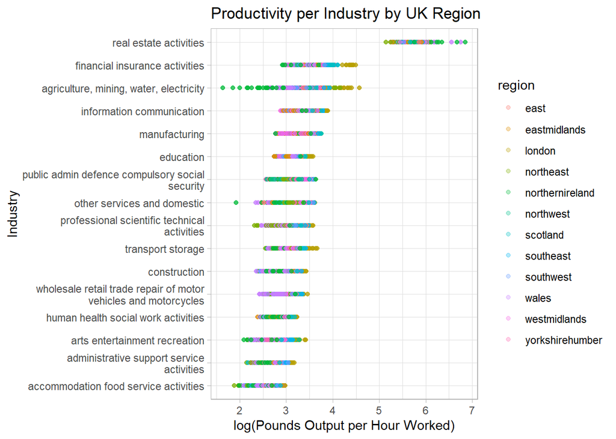

```r
model_base_data %>%
  select(region, industry_group, pounds_per_hour_worked) %>%
  group_by(region, industry_group) %>%
  ggplot() +
  aes(x = reorder(industry_group, pounds_per_hour_worked),
      y = log(pounds_per_hour_worked), colour = region) +
  geom_point(alpha = 0.3) +
  theme_light() +
  labs(title = "Productivity per Industry by UK Region",
       x = "Industry",
       y = "log(Pounds Output per Hour Worked)") +
  scale_x_discrete(labels = wrap_format(40)) +
  coord_flip()
```

### Agriculture, Mining, Water, Electricity

This industry grouping shows a very large spread of productivity which appears to be dependent on region:

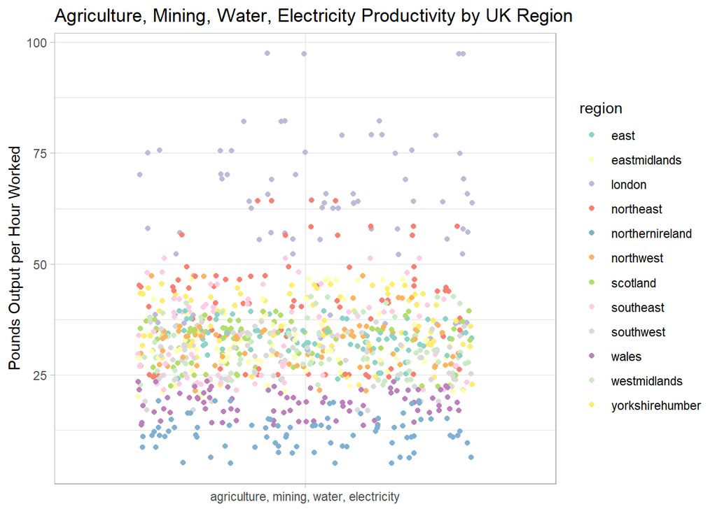

```r
model_base_data %>%
  filter(industry == "ABDE") %>%
  select(region, industry_group, pounds_per_hour_worked) %>%
  group_by(region, industry_group) %>%
  ggplot() +
  aes(x = reorder(industry_group, pounds_per_hour_worked),
      y = pounds_per_hour_worked, colour = region) +
  geom_jitter(height = 0.1) +
  theme_light() +
  labs(title = "Agriculture, Mining, Water, Electricity Productivity by UK Region",
       y = "Pounds Output per Hour Worked") +
  theme(axis.title.x = element_blank ()) +
  scale_colour_brewer(palette = "Set3")
```

This clearly shows stratification based on region, but there is insufficient data to be able to pinpoint exactly what is creating the difference. Is this more evident in a boxplot?

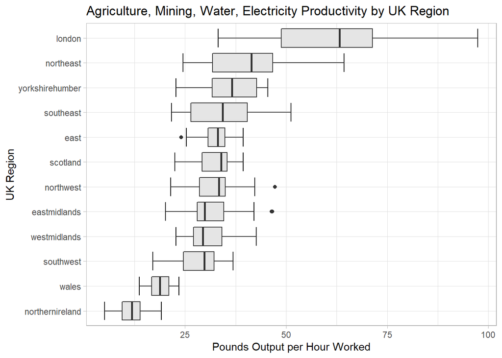

```r
model_base_data %>%
  filter(industry == "ABDE") %>%
  select(region, industry_group, pounds_per_hour_worked) %>%
  group_by(region, industry_group) %>%
  ggplot() +
  aes(x = reorder(region, pounds_per_hour_worked),
      y = pounds_per_hour_worked) +
  stat_boxplot(geom = "errorbar") +
  geom_boxplot(fill = "grey90") +
  theme_light() +
  labs(title = "Agriculture, Mining, Water, Electricity Productivity by UK Region",
       x = "UK Region",
       y = "Pounds Output per Hour Worked") +
  coord_flip()
```

Comparing London with Wales and N. Ireland there is very clearly a difference.

It’s not clear exactly how Agriculture, Mining, Water and Electricity output are measured, but there’s more scope for investigation in this respect. Doing so may provide an insight into improvement methodologies for the lower-scoring regions.

## Can UK Commuting Data be added to the model?

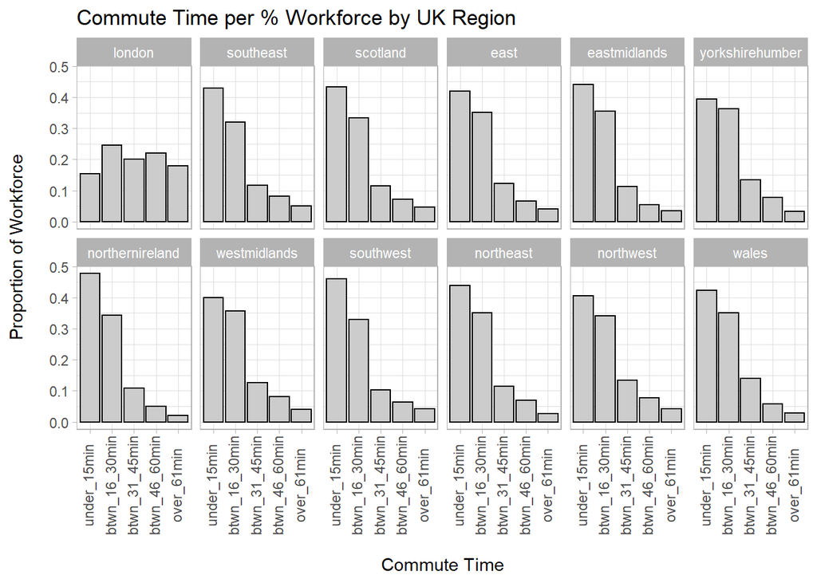

```r
model_commute_region %>%
  filter(region != "total") %>%
  mutate(commute_time = fct_relevel(commute_time, c("under_15min",
                                                    "btwn_16_30min",
                                                    "btwn_31_45min",
                                                    "btwn_46_60min",
                                                    "over_61min"))) %>%
  mutate(region = as.factor(region)) %>%
  mutate(region = fct_relevel(region, c("london",
                                        "southeast",
                                        "scotland",
                                        "east",
                                        "eastmidlands",
                                        "yorkshirehumber",
                                        "northernireland",
                                        "westmidlands",
                                        "southwest",
                                        "northeast",
                                        "northwest",
                                        "wales"))) %>%
  # factor_relevel to set the correct order of x-axis labels
  ggplot() +
  aes(x = commute_time, y = pcntge_workforce) +
  geom_col(fill = "grey80", colour = "black") +
  facet_wrap(~ region, nrow = 2) +
  theme_light() +
  theme(axis.text.x = element_text(angle = 90, vjust = 0.3)) +
  labs(title = "Commute Time per % Workforce by UK Region",
       x = "\nCommute Time",
       y = "Proportion of Workforce\n")
```

# Does employee age matter?

Pivot the data longer then change characters to factors;

```r
model_ages_long <- model_ages %>%
  pivot_longer(cols = contains("age"),
               names_to = "employee_age",
               values_to = "no_employed") %>%
  select(-industry) %>%
  mutate(across(where(is.character), .fns = as.factor))
```

[figure not shown]

```r
model_ages_long %>%
  ggplot() +
  aes(x = year) +
  geom_line(aes(y = no_employed/1000000,
      group = employee_age,
      colour = employee_age)) +
#  geom_line(aes(y = pounds_per_hour_worked, group = 1)) +
  geom_text(x = 2003,  y = 28,
           label = "Pounds per hour worked",
           colour = "black",
           size = 3) +
  theme_light() +
  labs(title = "UK Employment Numbers per Age Group",
       x = "Year",
       y = "No. Employed (millions)") +
  theme(legend.title = element_blank(),
        axis.text.x = element_text(angle = 90, hjust = 1, vjust = 0.5)) +
  scale_x_continuous(breaks=seq(1997, 2022, 1)) +
  scale_colour_discrete(labels = c("16 - 17 years old",
                                 "18 - 24 years old",
                                 "25 - 34 years old",
                                 "35 - 49 years old",
                                 "50 - 64 years old",
                                 "> 65 years old"))
```

No indication that age is significant…?

# Explanatory Model Setup: Region, No. Jobs, Industry Type

```r
model_dev <- model_base_data %>%
  select(-c(year, industry)) %>%
  mutate(year = year(quarter), .after = quarter)
```

#### Set Test-Train Split

```r
# Change character variables to factors
model_dev <- model_dev %>%
  mutate(region = as.factor(region),
         industry_group = as.factor(industry_group))


# Make a test index
test_index <- sample(1:nrow(model_dev), size = nrow(model_dev)*0.2)

# Use the test index to create test and training datasets
model_test  <- slice(model_dev, test_index)
model_train <- slice(model_dev, -test_index)
```

#### mod1a - Training Data

```r
mod1a_exh <- regsubsets(pounds_per_hour_worked ~ .,
                            data = model_train,
                            method = "exhaustive")
```

```r
summary_mod1a_exh <- summary(mod1a_exh)
summary_mod1a_exh
```

```
## Subset selection object
## Call: regsubsets.formula(pounds_per_hour_worked ~ ., data = model_train,
##     method = "exhaustive")
## 29 Variables  (and intercept)
##                                                                               Forced in
## regioneastmidlands                                                                FALSE
## regionlondon                                                                      FALSE
## regionnortheast                                                                   FALSE
## regionnorthernireland                                                             FALSE
## regionnorthwest                                                                   FALSE
## regionscotland                                                                    FALSE
## regionsoutheast                                                                   FALSE
## regionsouthwest                                                                   FALSE
## regionwales                                                                       FALSE
## regionwestmidlands                                                                FALSE
## regionyorkshirehumber                                                             FALSE
## quarter                                                                           FALSE
## year                                                                              FALSE
## avg_jobs_000                                                                      FALSE
## industry_groupadministrative support service activities                           FALSE
## industry_groupagriculture, mining, water, electricity                             FALSE
## industry_grouparts entertainment recreation                                       FALSE
## industry_groupconstruction                                                        FALSE
## industry_groupeducation                                                           FALSE
## industry_groupfinancial insurance activities                                      FALSE
## industry_grouphuman health social work activities                                 FALSE
## industry_groupinformation communication                                           FALSE
## industry_groupmanufacturing                                                       FALSE
## industry_groupother services and domestic                                         FALSE
## industry_groupprofessional scientific technical activities                        FALSE
## industry_grouppublic admin defence compulsory social security                     FALSE
## industry_groupreal estate activities                                              FALSE
## industry_grouptransport storage                                                   FALSE
## industry_groupwholesale retail trade repair of motor vehicles and motorcycles     FALSE
##                                                                               Forced out
## regioneastmidlands                                                                 FALSE
## regionlondon                                                                       FALSE
## regionnortheast                                                                    FALSE
## regionnorthernireland                                                              FALSE
## regionnorthwest                                                                    FALSE
```

[output cut: 137 more lines]

```
## 3  ( 1 ) "*"                                  " "
## 4  ( 1 ) "*"                                  " "
## 5  ( 1 ) "*"                                  " "
## 6  ( 1 ) "*"                                  " "
## 7  ( 1 ) "*"                                  " "
## 8  ( 1 ) "*"                                  " "
##          industry_groupwholesale retail trade repair of motor vehicles and motorcycles
## 1  ( 1 ) " "
## 2  ( 1 ) " "
## 3  ( 1 ) " "
## 4  ( 1 ) " "
## 5  ( 1 ) " "
## 6  ( 1 ) " "
## 7  ( 1 ) " "
## 8  ( 1 ) " "
```

It looks like industry type (particularly real estate and financial services) and region have an influence on productivity, along with `year` to a lesser extent. The average number of jobs in each region is insignificant.

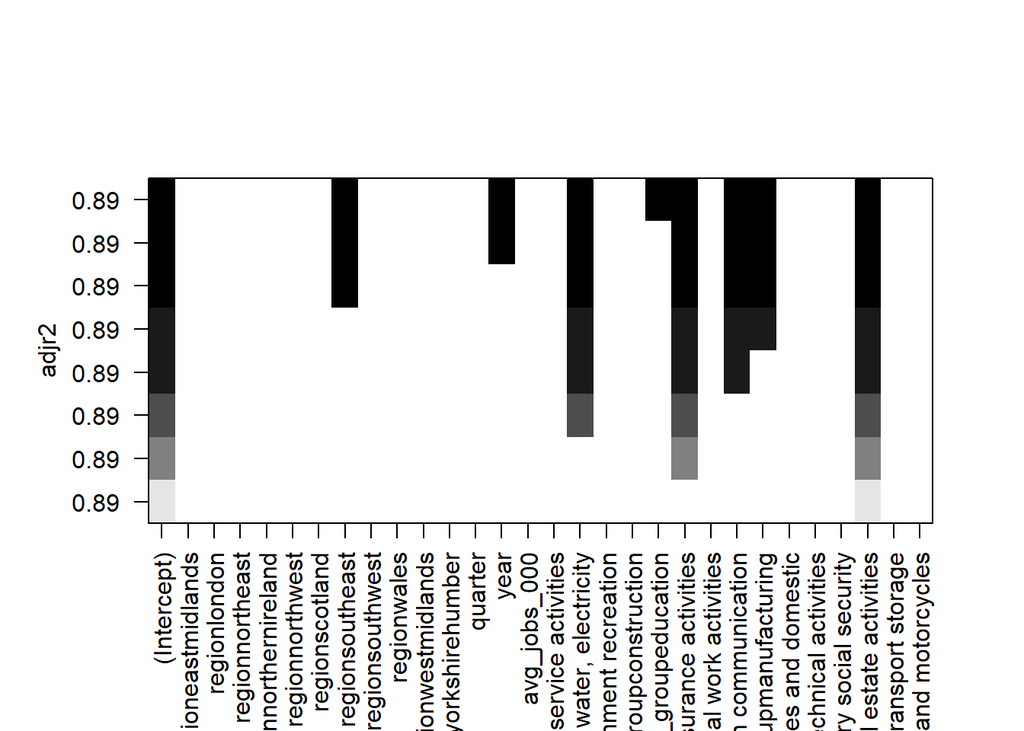

```r
plot(mod1a_exh, scale = "adjr2")
```

The plot confirms the original suggestion. Check against BIC:

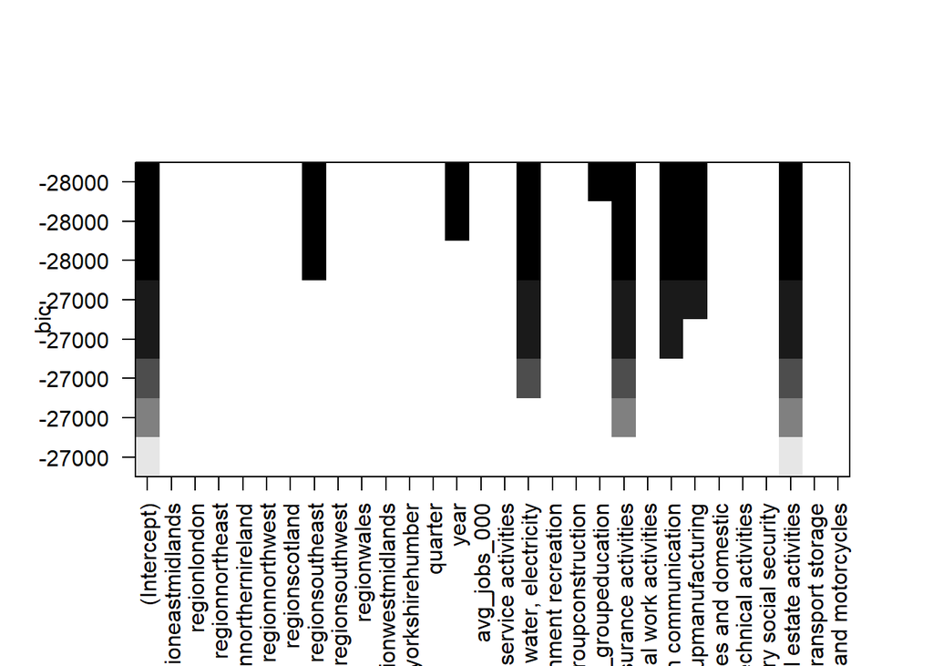

```r
plot(mod1a_exh, scale = "bic")
```

The lowest BIC score comes with industry type, region and year.

Although only certain industries and regions have been shown above to be influential predictors, they cannot be selected individually. If one industry or region is selected then they all need to be included.

The biggest influence comes from industry type.

```r
mod1a_no_industry <- lm(pounds_per_hour_worked ~ region + year,
                        data = model_train)
summary(mod1a_no_industry)
```

```
##
## Call:
## lm(formula = pounds_per_hour_worked ~ region + year, data = model_train)
##
## Residuals:
##    Min     1Q Median     3Q    Max
## -35.64 -23.74 -19.19 -12.27 906.70
##
## Coefficients:
##                        Estimate Std. Error t value Pr(>|t|)
## (Intercept)           -455.1832   230.9749  -1.971   0.0488 *
## regioneastmidlands      -2.2107     3.2626  -0.678   0.4980
## regionlondon             0.8879     3.2548   0.273   0.7850
## regionnortheast         -3.3904     3.2634  -1.039   0.2989
## regionnorthernireland   -0.3441     3.2745  -0.105   0.9163
## regionnorthwest         -3.2116     3.2634  -0.984   0.3251
## regionscotland          -0.4938     3.2690  -0.151   0.8799
## regionsoutheast          4.2218     3.2603   1.295   0.1954
## regionsouthwest         -6.1226     3.2754  -1.869   0.0616 .
## regionwales             -0.8637     3.2587  -0.265   0.7910
## regionwestmidlands      -5.4697     3.2737  -1.671   0.0948 .
## regionyorkshirehumber   -2.4695     3.2667  -0.756   0.4497
## year                     0.2480     0.1151   2.154   0.0312 *
## ---
## Signif. codes:  0 '***' 0.001 '**' 0.01 '*' 0.05 '.' 0.1 ' ' 1
##
## Residual standard error: 73.68 on 12275 degrees of freedom
## Multiple R-squared:  0.001733,   Adjusted R-squared:  0.0007566
## F-statistic: 1.775 on 12 and 12275 DF,  p-value: 0.04624
```

```r
mod1a_with_industry <- lm(pounds_per_hour_worked ~ industry_group + region + year,
                        data = model_train)
summary(mod1a_with_industry)
```

```
##
## Call:
## lm(formula = pounds_per_hour_worked ~ industry_group + region +
##     year, data = model_train)
##
## Residuals:
##     Min      1Q  Median      3Q     Max
## -135.80   -3.34   -0.10    2.95  636.89
##
## Coefficients:
##                                                                                 Estimate
## (Intercept)                                                                   -465.02187
## industry_groupadministrative support service activities                          1.96390
## industry_groupagriculture, mining, water, electricity                           19.67594
## industry_grouparts entertainment recreation                                      2.64058
## industry_groupconstruction                                                       6.24955
## industry_groupeducation                                                         11.05133
## industry_groupfinancial insurance activities                                    26.25052
## industry_grouphuman health social work activities                                4.87602
## industry_groupinformation communication                                         18.99415
## industry_groupmanufacturing                                                     13.36771
## industry_groupother services and domestic                                        9.77562
## industry_groupprofessional scientific technical activities                       7.91088
## industry_grouppublic admin defence compulsory social security                   10.25722
## industry_groupreal estate activities                                           296.09245
## industry_grouptransport storage                                                  7.72079
## industry_groupwholesale retail trade repair of motor vehicles and motorcycles    5.38436
## regioneastmidlands                                                              -1.99220
## regionlondon                                                                     2.12046
## regionnortheast                                                                 -2.96129
## regionnorthernireland                                                            1.62777
## regionnorthwest                                                                 -3.86932
## regionscotland                                                                  -0.42473
## regionsoutheast                                                                  3.94819
## regionsouthwest                                                                 -3.91213
## regionwales                                                                      0.11551
## regionwestmidlands                                                              -4.30104
## regionyorkshirehumber                                                           -1.73887
## year                                                                             0.23875
##                                                                               Std. Error
```

[output cut: 106 more lines]

```
## regionnorthernireland
## regionnorthwest                                                               ***
## regionscotland
## regionsoutheast                                                               ***
## regionsouthwest                                                               ***
## regionwales
## regionwestmidlands                                                            ***
## regionyorkshirehumber                                                         .
## year                                                                          ***
## ---
## Signif. codes:  0 '***' 0.001 '**' 0.01 '*' 0.05 '.' 0.1 ' ' 1
##
## Residual standard error: 23.71 on 12260 degrees of freedom
## Multiple R-squared:  0.8967, Adjusted R-squared:  0.8965
## F-statistic:  3943 on 27 and 12260 DF,  p-value: < 2.2e-16
```

```r
anova(mod1a_no_industry, mod1a_with_industry)
```

```
## Analysis of Variance Table
##
## Model 1: pounds_per_hour_worked ~ region + year
## Model 2: pounds_per_hour_worked ~ industry_group + region + year
##   Res.Df      RSS Df Sum of Sq      F    Pr(>F)
## 1  12275 66632485
## 2  12260  6893452 15  59739033 7083.1 < 2.2e-16 ***
## ---
## Signif. codes:  0 '***' 0.001 '**' 0.01 '*' 0.05 '.' 0.1 ' ' 1
```

The model with `industry_group` is more significant than the model without, so it should be the main part of the model.

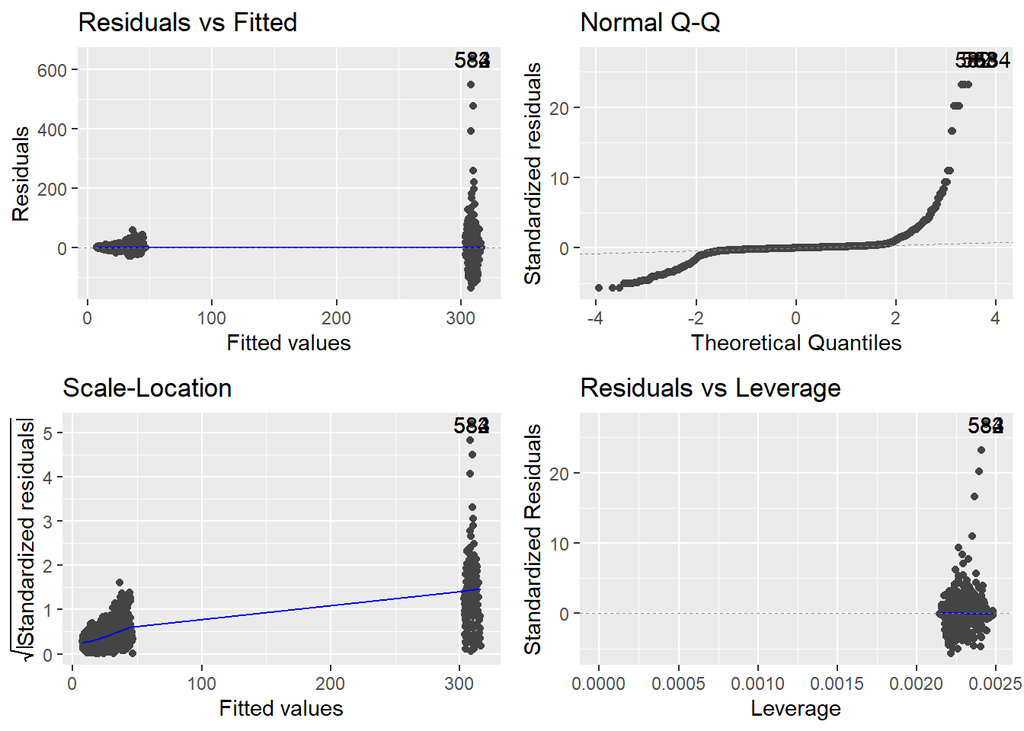

```r
autoplot(mod1a_with_industry)
```

### Model with Test Data

```r
mod1_test <- regsubsets(pounds_per_hour_worked ~ .,
                            data = model_test,
                            method = "exhaustive")
```

```r
summary_mod1_test <- summary(mod1_test)
summary_mod1_test
```

```
## Subset selection object
## Call: regsubsets.formula(pounds_per_hour_worked ~ ., data = model_test,
##     method = "exhaustive")
## 29 Variables  (and intercept)
##                                                                               Forced in
## regioneastmidlands                                                                FALSE
## regionlondon                                                                      FALSE
## regionnortheast                                                                   FALSE
## regionnorthernireland                                                             FALSE
## regionnorthwest                                                                   FALSE
## regionscotland                                                                    FALSE
## regionsoutheast                                                                   FALSE
## regionsouthwest                                                                   FALSE
## regionwales                                                                       FALSE
## regionwestmidlands                                                                FALSE
## regionyorkshirehumber                                                             FALSE
## quarter                                                                           FALSE
## year                                                                              FALSE
## avg_jobs_000                                                                      FALSE
## industry_groupadministrative support service activities                           FALSE
## industry_groupagriculture, mining, water, electricity                             FALSE
## industry_grouparts entertainment recreation                                       FALSE
## industry_groupconstruction                                                        FALSE
## industry_groupeducation                                                           FALSE
## industry_groupfinancial insurance activities                                      FALSE
## industry_grouphuman health social work activities                                 FALSE
## industry_groupinformation communication                                           FALSE
## industry_groupmanufacturing                                                       FALSE
## industry_groupother services and domestic                                         FALSE
## industry_groupprofessional scientific technical activities                        FALSE
## industry_grouppublic admin defence compulsory social security                     FALSE
## industry_groupreal estate activities                                              FALSE
## industry_grouptransport storage                                                   FALSE
## industry_groupwholesale retail trade repair of motor vehicles and motorcycles     FALSE
##                                                                               Forced out
## regioneastmidlands                                                                 FALSE
## regionlondon                                                                       FALSE
## regionnortheast                                                                    FALSE
## regionnorthernireland                                                              FALSE
## regionnorthwest                                                                    FALSE
```

[output cut: 137 more lines]

```
## 3  ( 1 ) "*"                                  " "
## 4  ( 1 ) "*"                                  " "
## 5  ( 1 ) "*"                                  " "
## 6  ( 1 ) "*"                                  " "
## 7  ( 1 ) "*"                                  " "
## 8  ( 1 ) "*"                                  " "
##          industry_groupwholesale retail trade repair of motor vehicles and motorcycles
## 1  ( 1 ) " "
## 2  ( 1 ) " "
## 3  ( 1 ) " "
## 4  ( 1 ) " "
## 5  ( 1 ) " "
## 6  ( 1 ) " "
## 7  ( 1 ) " "
## 8  ( 1 ) " "
```

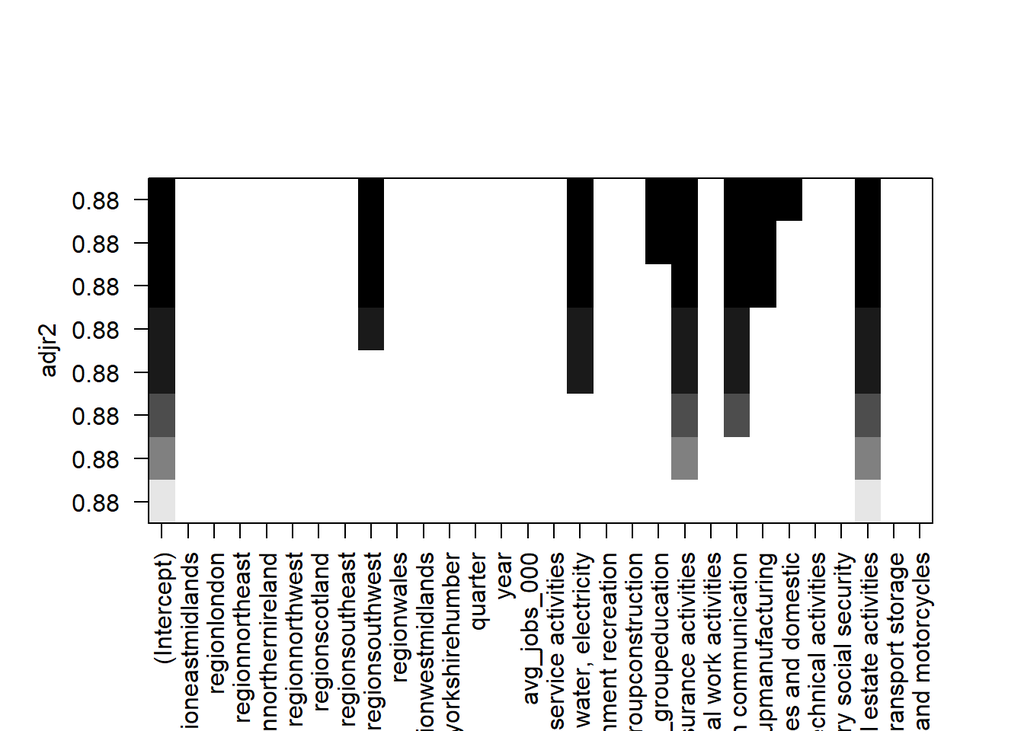

```r
plot(mod1_test, scale = "adjr2")
```

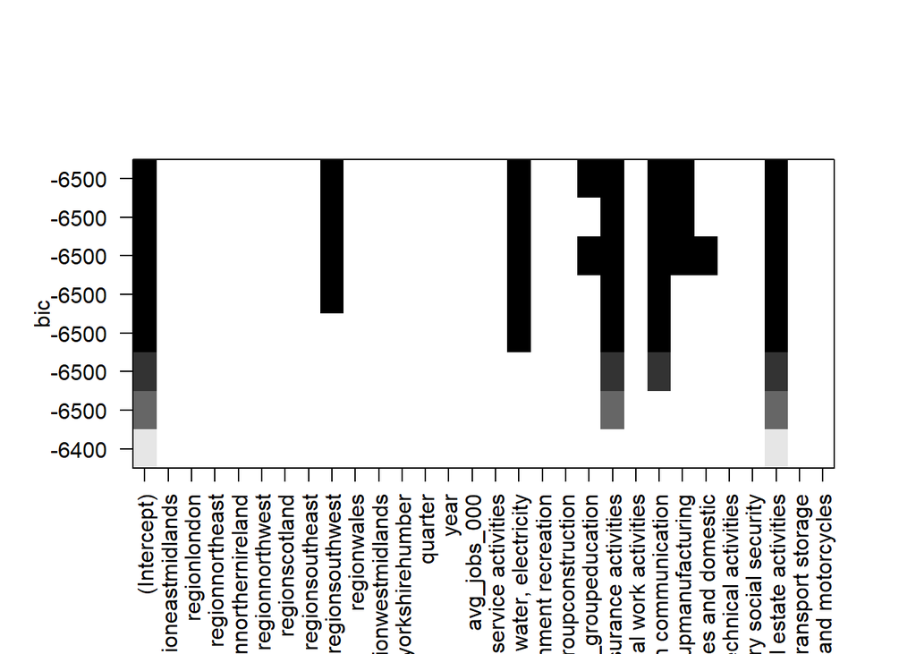

```r
plot(mod1_test, scale = "bic")
```

Again, region and industry are the main influencing factors.

Although only certain industries have been shown to be influential predictors, they cannot be selected individually. If one industry or region is selected then they all need to be included.

Check which predictors are most significant;

```r
mod1_test_no_industry <- lm(pounds_per_hour_worked ~ region + year,
                        data = model_dev)
summary(mod1_test_no_industry)
```

```
##
## Call:
## lm(formula = pounds_per_hour_worked ~ region + year, data = model_dev)
##
## Residuals:
##    Min     1Q Median     3Q    Max
## -36.27 -23.81 -19.26 -12.16 905.17
##
## Coefficients:
##                        Estimate Std. Error t value Pr(>|t|)
## (Intercept)           -378.4215   207.6251  -1.823   0.0684 .
## regioneastmidlands      -1.7018     2.9229  -0.582   0.5604
## regionlondon             2.0775     2.9229   0.711   0.4772
## regionnortheast         -2.9169     2.9229  -0.998   0.3183
## regionnorthernireland    1.5340     2.9229   0.525   0.5997
## regionnorthwest         -3.6724     2.9229  -1.256   0.2090
## regionscotland          -0.4798     2.9229  -0.164   0.8696
## regionsoutheast          3.8000     2.9229   1.300   0.1936
## regionsouthwest         -4.3892     2.9229  -1.502   0.1332
## regionwales              0.8093     2.9229   0.277   0.7819
## regionwestmidlands      -4.1780     2.9229  -1.429   0.1529
## regionyorkshirehumber   -1.5085     2.9229  -0.516   0.6058
## year                     0.2094     0.1035   2.023   0.0431 *
## ---
## Signif. codes:  0 '***' 0.001 '**' 0.01 '*' 0.05 '.' 0.1 ' ' 1
##
## Residual standard error: 73.95 on 15347 degrees of freedom
## Multiple R-squared:  0.001431,   Adjusted R-squared:  0.0006504
## F-statistic: 1.833 on 12 and 15347 DF,  p-value: 0.03766
```

```r
mod1_test_with_industry <- lm(pounds_per_hour_worked ~ industry_group + region + year,
                        data = model_dev)
summary(mod1_test_with_industry)
```

```
##
## Call:
## lm(formula = pounds_per_hour_worked ~ industry_group + region +
##     year, data = model_dev)
##
## Residuals:
##     Min      1Q  Median      3Q     Max
## -136.68   -3.53   -0.02    3.10  635.77
##
## Coefficients:
##                                                                                 Estimate
## (Intercept)                                                                   -406.17551
## industry_groupadministrative support service activities                          2.05658
## industry_groupagriculture, mining, water, electricity                           19.57222
## industry_grouparts entertainment recreation                                      2.64521
## industry_groupconstruction                                                       6.38715
## industry_groupeducation                                                         11.09757
## industry_groupfinancial insurance activities                                    26.27022
## industry_grouphuman health social work activities                                4.89852
## industry_groupinformation communication                                         19.15737
## industry_groupmanufacturing                                                     13.30887
## industry_groupother services and domestic                                        9.93743
## industry_groupprofessional scientific technical activities                       8.02900
## industry_grouppublic admin defence compulsory social security                   10.24636
## industry_groupreal estate activities                                           297.15869
## industry_grouptransport storage                                                  7.75865
## industry_groupwholesale retail trade repair of motor vehicles and motorcycles    5.53992
## regioneastmidlands                                                              -1.70181
## regionlondon                                                                     2.07749
## regionnortheast                                                                 -2.91690
## regionnorthernireland                                                            1.53405
## regionnorthwest                                                                 -3.67241
## regionscotland                                                                  -0.47981
## regionsoutheast                                                                  3.79999
## regionsouthwest                                                                 -4.38921
## regionwales                                                                      0.80926
## regionwestmidlands                                                              -4.17796
## regionyorkshirehumber                                                           -1.50851
## year                                                                             0.20936
##                                                                               Std. Error
```

[output cut: 106 more lines]

```
## regionnorthernireland
## regionnorthwest                                                               ***
## regionscotland
## regionsoutheast                                                               ***
## regionsouthwest                                                               ***
## regionwales
## regionwestmidlands                                                            ***
## regionyorkshirehumber
## year                                                                          ***
## ---
## Signif. codes:  0 '***' 0.001 '**' 0.01 '*' 0.05 '.' 0.1 ' ' 1
##
## Residual standard error: 24.08 on 15332 degrees of freedom
## Multiple R-squared:  0.8942, Adjusted R-squared:  0.8941
## F-statistic:  4801 on 27 and 15332 DF,  p-value: < 2.2e-16
```

```r
anova(mod1_test_no_industry, mod1_test_with_industry)
```

```
## Analysis of Variance Table
##
## Model 1: pounds_per_hour_worked ~ region + year
## Model 2: pounds_per_hour_worked ~ industry_group + region + year
##   Res.Df      RSS Df Sum of Sq      F    Pr(>F)
## 1  15347 83915947
## 2  15332  8887778 15  75028169 8628.6 < 2.2e-16 ***
## ---
## Signif. codes:  0 '***' 0.001 '**' 0.01 '*' 0.05 '.' 0.1 ' ' 1
```

The model with `industry_group` is still more significant than the model without, so it should be the main part of the model.

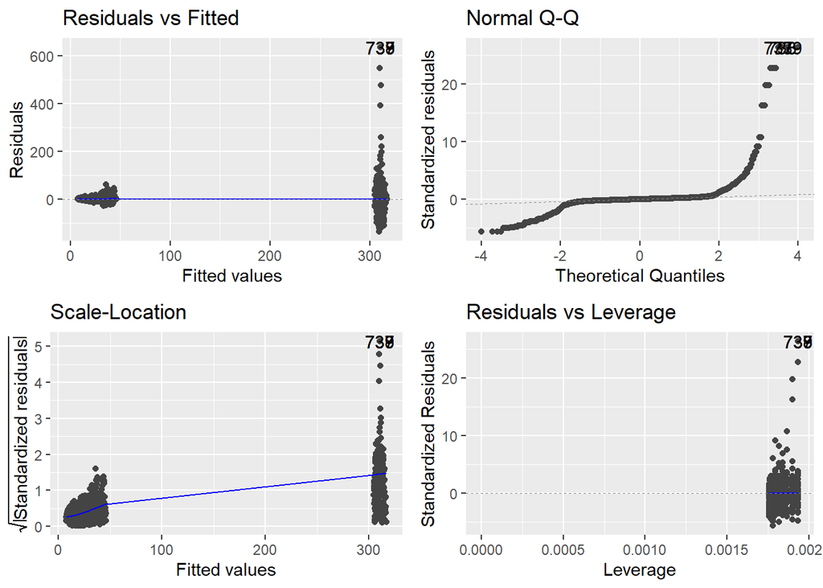

```r
autoplot(mod1_test_with_industry)
```

# Explanatory Model Summary

The diagnostic plots show a reasonable residuals v fitted, with a spread over the x-axis and a horizontal line, although there is some grouping evident.

In summary, the productivity within the UK can be described as factors of industry type and region, or:

$$pounds\_per\_hour\_worked \sim
industry\_group + region + year$$

# Explanatory Model 2: Education

An explanatory model describing the influence of education had been planned, but after cleaning for UK data there were only 20 observations upon which to build a model, which seems insufficient to develop a test train split. Is cross validation an option?

# Generate a Plot of the Linear Model against Data —-

```r
model_fcast <- model_dev %>%
  select(-c(quarter, avg_jobs_000)) %>%
  filter(region != "uk") %>%
  unique() %>%
  add_predictions(mod1a_with_industry) %>%
  add_residuals(mod1a_with_industry)


region <- model_fcast$region
industry_group <- model_fcast$industry_group
pounds_per_hour_worked <- model_fcast$pounds_per_hour_worked


model_17 <- 2017 %>%
  year_prediction()
model_18 <- 2018 %>%
  year_prediction()
model_19 <- 2019 %>%
  year_prediction()
model_20 <- 2020 %>%
  year_prediction()
model_21 <- 2021 %>%
  year_prediction()
model_22 <- 2022 %>%
  year_prediction()
model_23 <- 2023 %>%
  year_prediction()
model_24 <- 2024 %>%
  year_prediction()
model_25 <- 2025 %>%
  year_prediction()
model_26 <- 2026 %>%
  year_prediction()
```

Plot the original data versus predictions, 1997 - 2016;

```r
model_fcast_annual <- model_fcast %>%
  select(-c(industry_group, region)) %>%
  group_by(year) %>%
  summarise(total_productivity = sum(pounds_per_hour_worked),
            total_predicted = sum(pred))

head(model_fcast_annual)
```

```
## # A tibble: 6 x 3
##    year total_productivity total_predicted
##   <dbl>              <dbl>           <dbl>
## 1  1997              7938.           7383.
## 2  1998              7827.           7428.
## 3  1999              7407.           7474.
## 4  2000              7504.           7520.
## 5  2001              7510.           7566.
## 6  2002              7726.           7612.
```

## Plot Residuals;

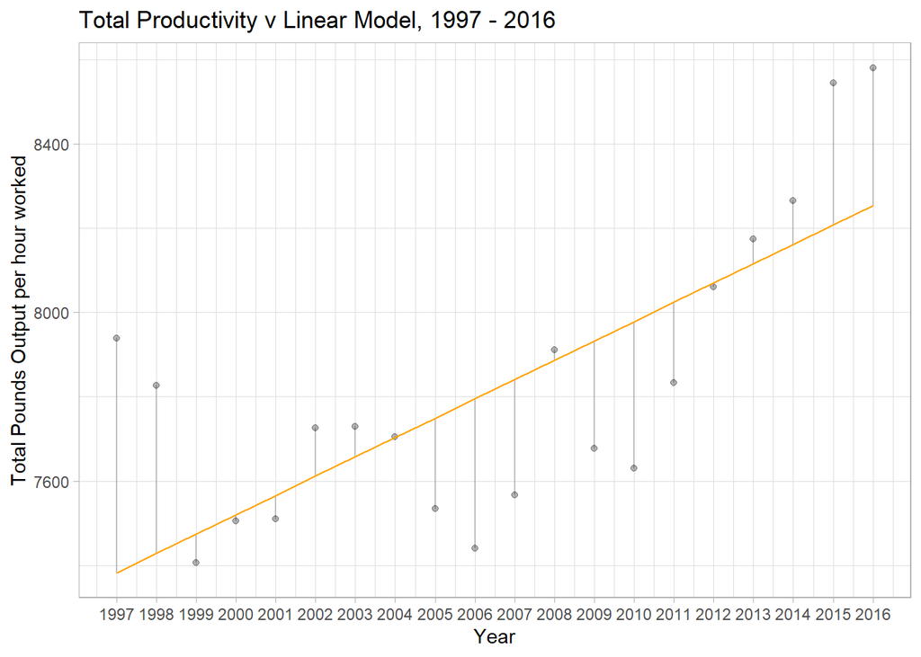

```r
model_fcast_annual %>%
  ggplot() +
  aes(x = year, y = total_predicted) +
  geom_point(aes(y = total_productivity), alpha = 0.3) +
  geom_segment(aes(xend = year, yend = total_productivity), alpha = 0.2) +
  geom_line(aes(y = total_predicted), colour = "orange") +
  theme_light() +
  scale_x_continuous(breaks=seq(1997, 2016, 1)) +
  labs(title = "Total Productivity v Linear Model, 1997 - 2016",
       x = "Year",
       y = "Total Pounds Output per hour worked")
```

Plotting the existing data as a line instead of scatterplot;

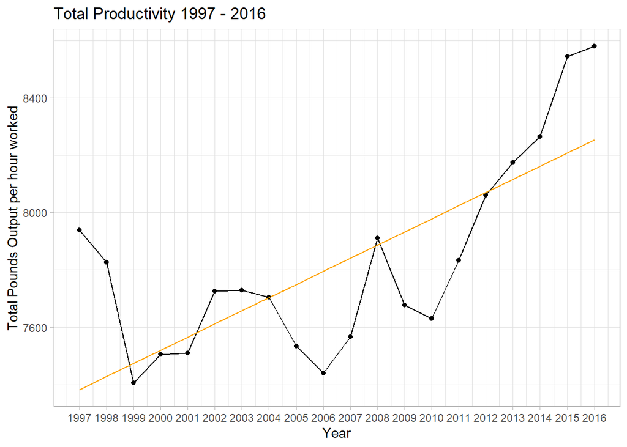

```r
model_fcast_annual %>%
  ggplot() +
  aes(x = year, y = total_productivity) +
  geom_point() +
  geom_line() +
  geom_line(aes(y = total_predicted), colour = "orange") +
  theme_light() +
  scale_x_continuous(breaks=seq(1997, 2016, 1)) +
  labs(title = "Total Productivity 1997 - 2016",
       x = "Year",
       y = "Total Pounds Output per hour worked")
```

And add in the predictive model;

```r
# ONE year at a time, otherwise memory overload happens...

model_17_annual <- model_17 %>%
  prediction()

model_18_annual <- model_18 %>%
  prediction()

model_19_annual <- model_19 %>%
  prediction()

model_20_annual <- model_20 %>%
  prediction()

model_21_annual <- model_21 %>%
  prediction()

model_22_annual <- model_22 %>%
  prediction()

model_23_annual <- model_23 %>%
  prediction()

model_24_annual <- model_24 %>%
  prediction()

model_25_annual <- model_25 %>%
  prediction()

model_26_annual <- model_26 %>%
  prediction()
```

And plot the predictions onto the previous line;

```r
model_all_predictions <- model_17_annual %>%
  full_join(model_18_annual, by = c("year", "total_predicted")) %>%
  full_join(model_19_annual, by = c("year", "total_predicted")) %>%
  full_join(model_20_annual, by = c("year", "total_predicted")) %>%
  full_join(model_21_annual, by = c("year", "total_predicted")) %>%
  full_join(model_22_annual, by = c("year", "total_predicted")) %>%
  full_join(model_23_annual, by = c("year", "total_predicted")) %>%
  full_join(model_24_annual, by = c("year", "total_predicted")) %>%
  full_join(model_25_annual, by = c("year", "total_predicted")) %>%
  full_join(model_26_annual, by = c("year", "total_predicted"))

model_all_predictions
```

```
## # A tibble: 10 x 2
##     year total_predicted
##    <dbl>           <dbl>
##  1  2017           8299.
##  2  2018           8345.
##  3  2019           8391.
##  4  2020           8437.
##  5  2021           8483.
##  6  2022           8529.
##  7  2023           8574.
##  8  2024           8620.
##  9  2025           8666.
## 10  2026           8712.
```

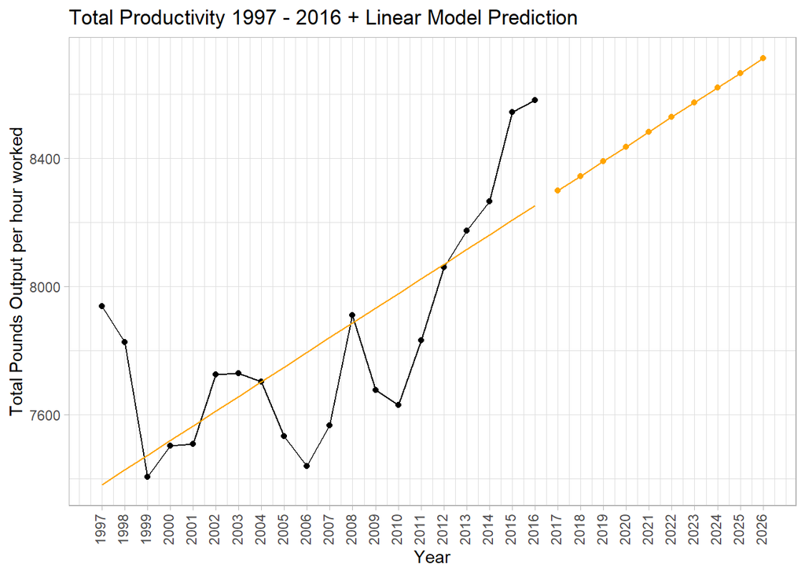

```r
model_fcast_annual %>%
  ggplot() +
  aes(x = year, y = total_productivity) +
  geom_point() +
  geom_line() +
  geom_line(data = model_all_predictions, aes(y = total_predicted), colour = "orange") +
  geom_point(data = model_all_predictions, aes(y = total_predicted), colour = "orange") +
  geom_line(aes(y = total_predicted), colour = "orange") +
  theme_light() +
  scale_x_continuous(breaks=seq(1997, 2026, 1)) +
  theme(axis.text.x = element_text(angle = 90, vjust = 0.3)) +
  labs(title = "Total Productivity 1997 - 2016 + Linear Model Prediction",
       x = "Year",
       y = "Total Pounds Output per hour worked")
```

```r
  # geom_smooth(method = "lm")
```

# Predict using `broom::`

```r
augment_trial <- augment(mod1a_with_industry,
        newdata = model_test,
        se_fit = TRUE,
        interval = "prediction")
head(augment_trial)
```

```
## # A tibble: 6 x 11
##   region      pounds_per_hour~ quarter  year avg_jobs_000 industry_group .fitted
##   <fct>                  <dbl>   <qtr> <dbl>        <dbl> <fct>            <dbl>
## 1 northwest               13.1 2006 Q3  2006          221 accommodation~    10.0
## 2 eastmidlan~             23.3 2012 Q3  2012          136 professional ~    21.3
## 3 wales                   17.4 2007 Q1  2007           67 professional ~    22.2
## 4 northwest               18.5 2003 Q4  2003          156 transport sto~    17.0
## 5 southeast               30.2 2009 Q3  2009          145 other service~    28.4
## 6 eastmidlan~             29.5 2003 Q1  2003           47 financial ins~    37.5
## # ... with 4 more variables: .lower <dbl>, .upper <dbl>, .se.fit <dbl>,
## #   .resid <dbl>
```

```r
glance(mod1a_with_industry)
```

```
## # A tibble: 1 x 12
##   r.squared adj.r.squared sigma statistic p.value    df  logLik     AIC     BIC
##       <dbl>         <dbl> <dbl>     <dbl>   <dbl> <dbl>   <dbl>   <dbl>   <dbl>
## 1     0.897         0.896  23.7     3943.       0    27 -56326. 112709. 112924.
## # ... with 3 more variables: deviance <dbl>, df.residual <int>, nobs <int>
```

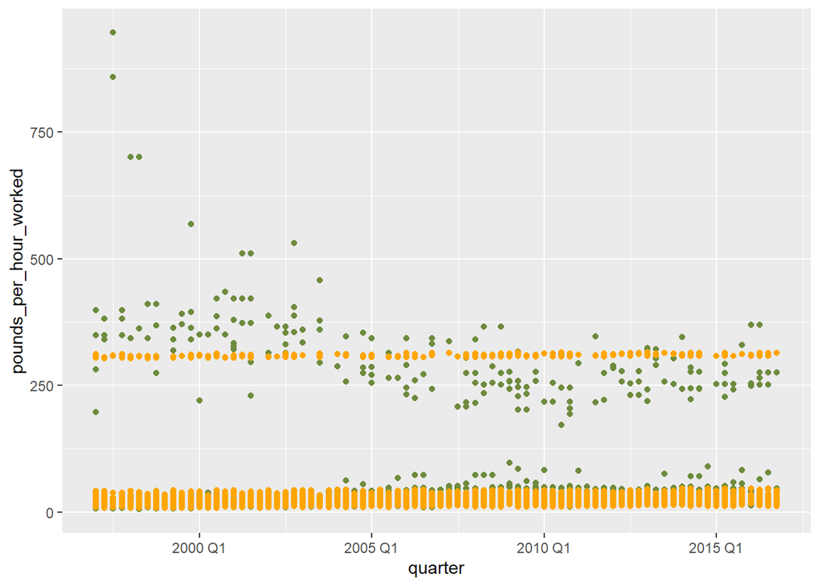

```r
augment_trial %>%
  ggplot() +
  geom_point(aes(x = quarter, y = pounds_per_hour_worked), colour = "darkolivegreen4") +
  geom_point(aes(x = quarter, y = .fitted), colour = "orange")
```

Covid impact: https://www.bbc.co.uk/news/business-52991913